# **Project nhóm 2**

# **Danh sách thành viên:**

| STT | Name | MSSV |
| --- | --- | --- |
| 9 | Nguyễn Trí Dũng | 20133029 |
| 10 | Lê Minh Đăng | 20133034 |
| 30 | Nguyễn Khoa Quang Thắng | 20133090 |

# Phần 1: Giới thiệu:

Điện thoại - Vật dụng không thể thiếu trong cuộc sống hiện nay khi mà toàn cầu đang tiến tới công nghệ hóa mọi thứ trong cuộc sống. Với những chức năng đa dạng và ngày càng hiện đại (như soạn văn bản Word, xem phim với độ phân giải cao,…), cộng thêm những chiếc điện thoại ngày nay có khả năng được những thiết bị khác (như máy ảnh, máy nhắn tin, máy ghi âm,…) thì việc càng nhiều người chọn điện thoại là vật bất ly thân là không thể chối cãi.

Nhận thấy điều đó, nhóm 2 nhận thức được rằng việc người mua hàng lựa chọn cấu hình và giá cả khi mua điện thoại luôn được người tiêu dùng đặt lên hàng đầu. Do vậy, để hiểu rõ hơn về sự ảnh hưởng của những chức năng, cấu hình điện thoại tới giá cả, nhóm 2 chọn đề tài là: “Phân tích mô hình dự đoán giá điện thoại qua cấu hình máy”.

Và trong đề tài này, dataset được nhóm 2 thống nhất sử dụng có tên là **Mobile Phone Specifications and Prices** được tải xuống từ Kaggle và tác giả của dataset là **PRATIK** **GARAI.** Theo tác giả, dataset được lấy từ website Gadgets360 - là một trang báo của Ấn Độ được cập nhật các thông tin trên toàn thế giới, dữ liệu từ trang này được scrapped và cleaned bằng cách dùng [code ở đây](https://github.com/PratikGarai/Web-Scrapers/blob/master/BeautifulSoup/Ndtv_Scraper.py) và preprocessed [ở đây](https://github.com/PratikGarai/Mobile-Phone-Dataset-Analysis/blob/master/Additional/ndtv_analysis.ipynb)

[figure not shown]

# Phần 2: Mô hình hoá dữ liệu:

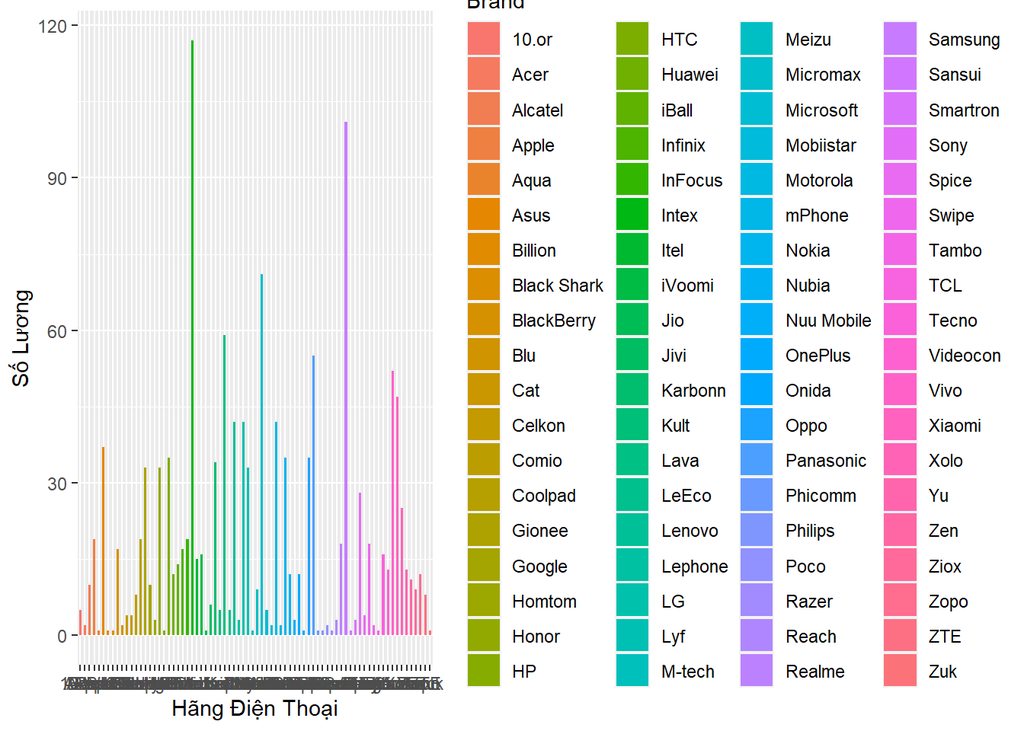

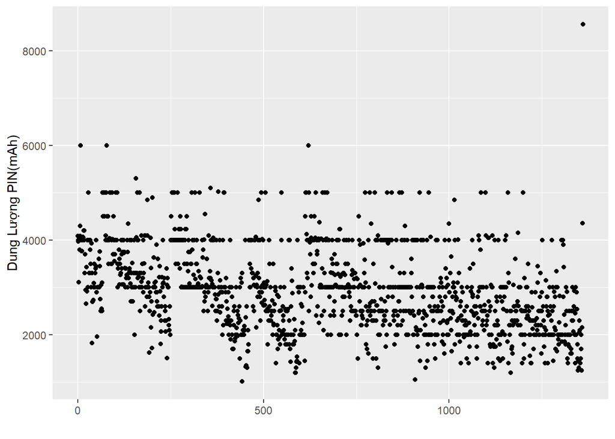

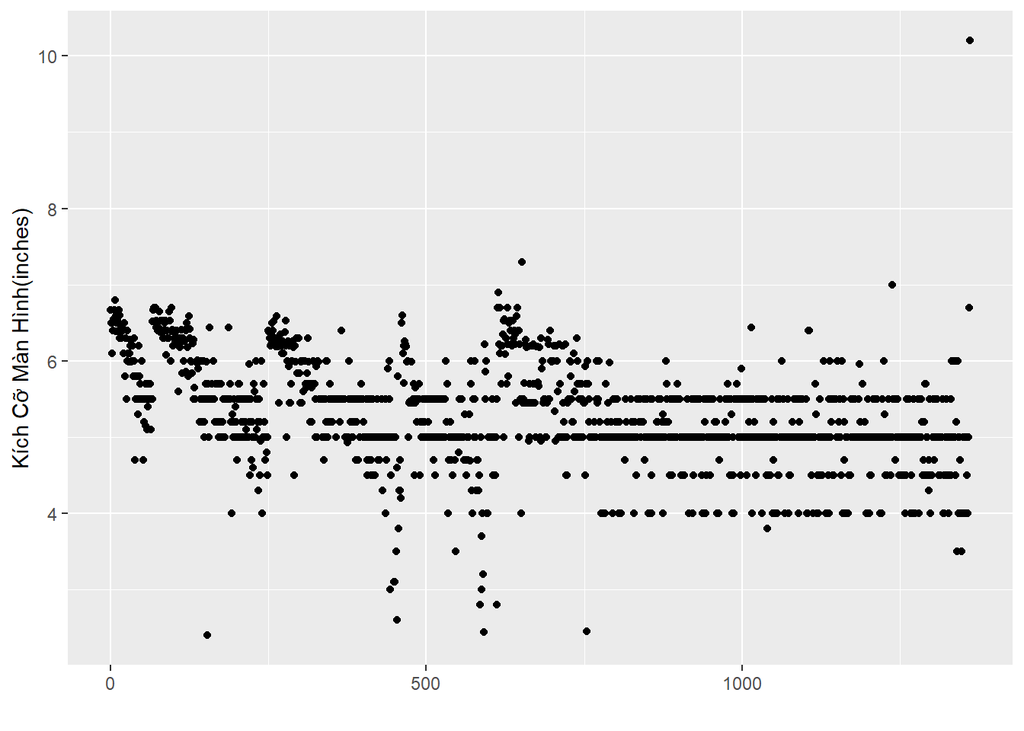

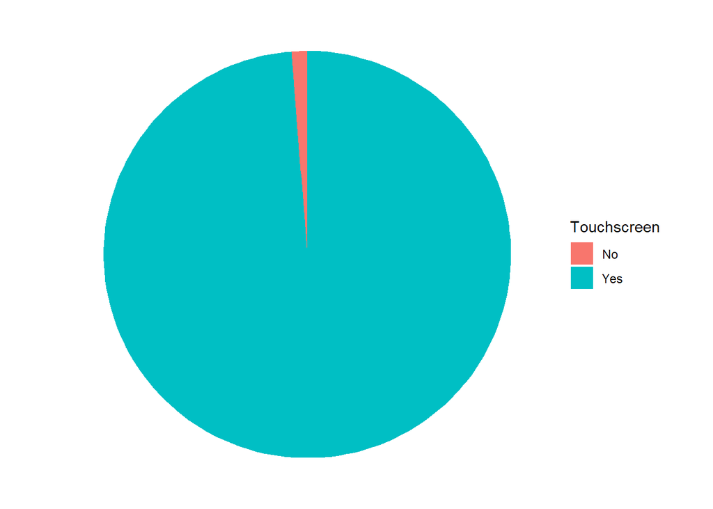

[figure not shown]

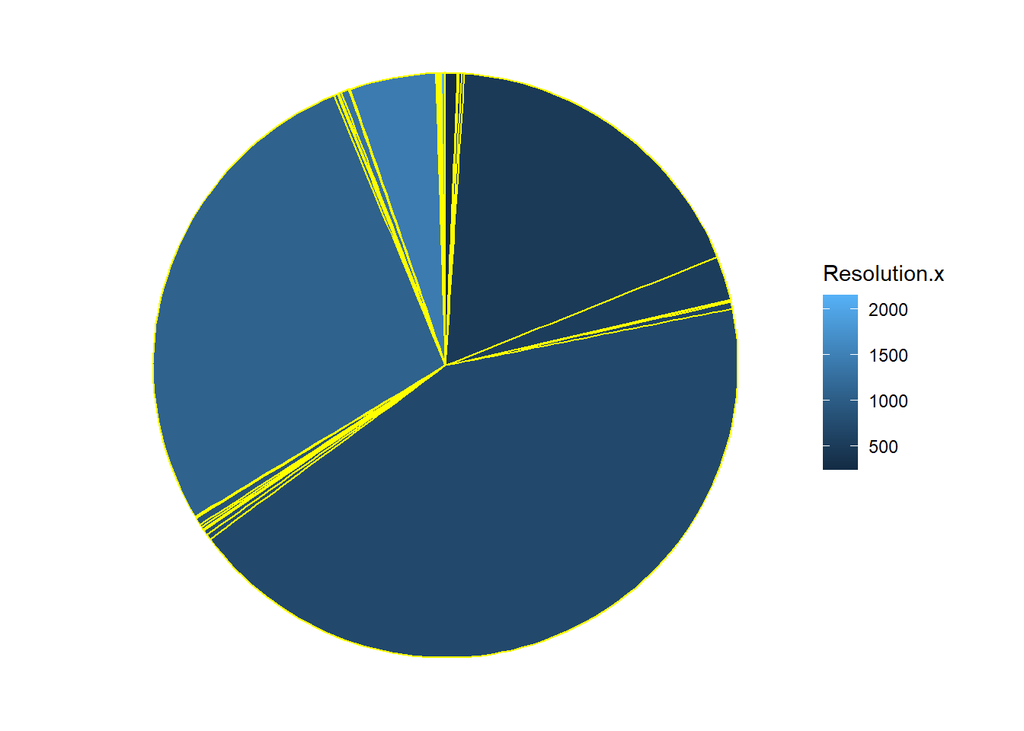

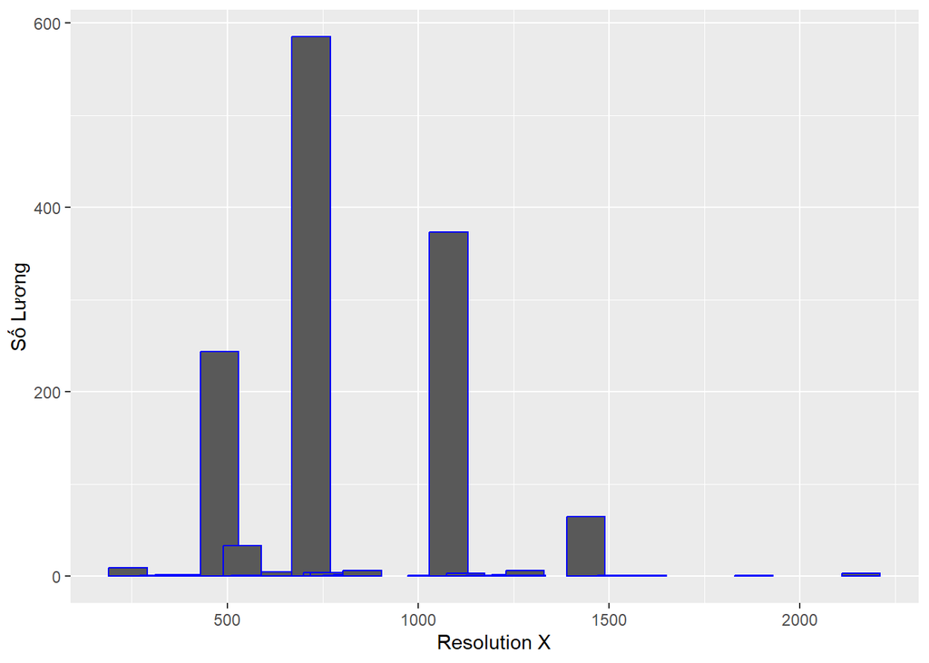

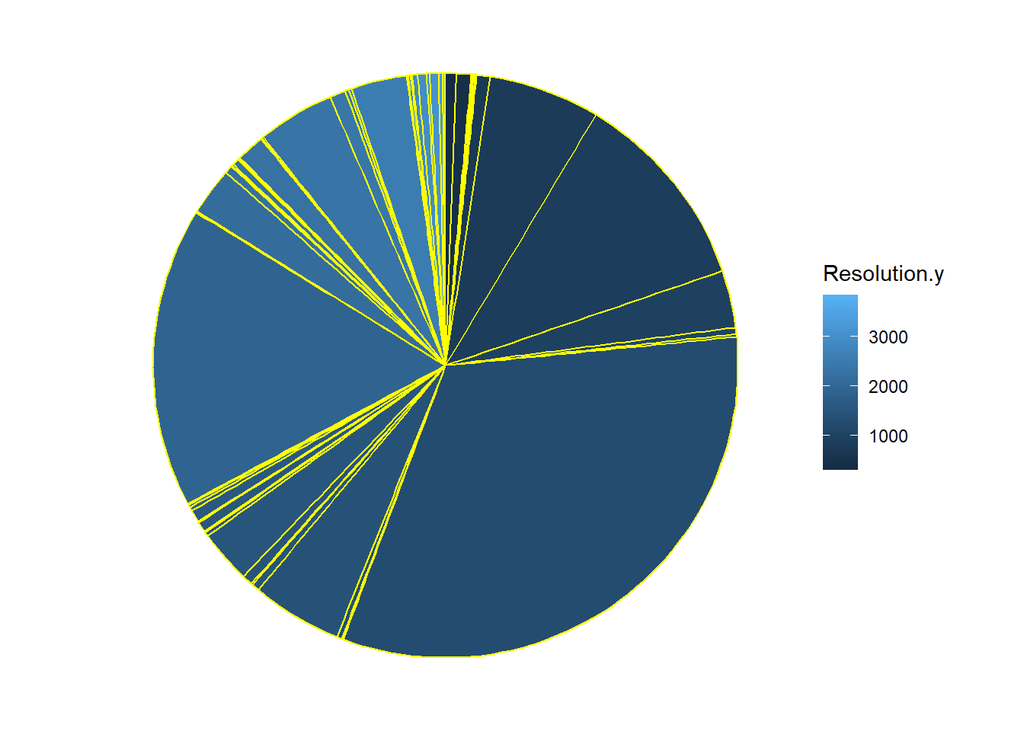

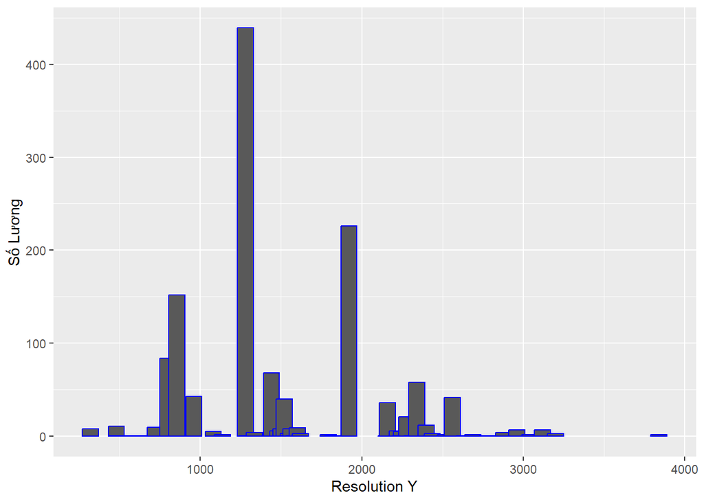

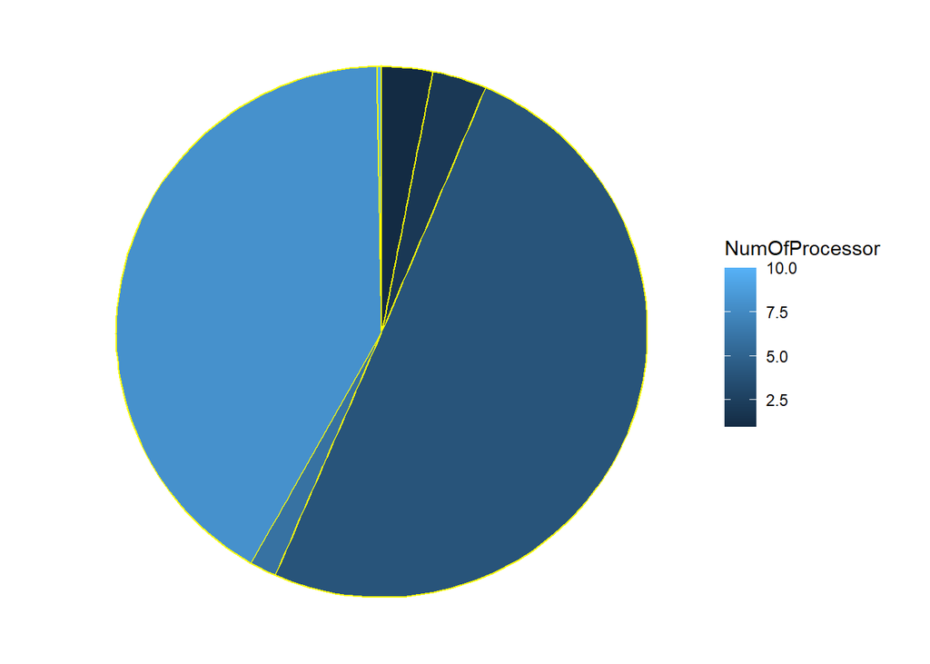

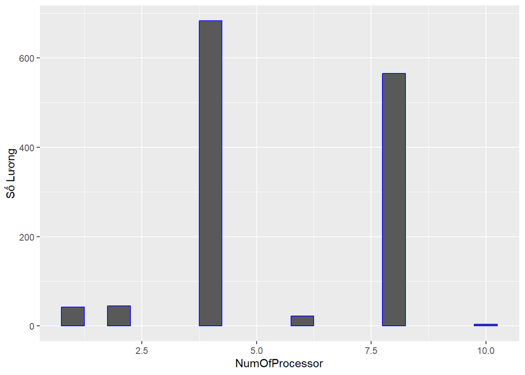

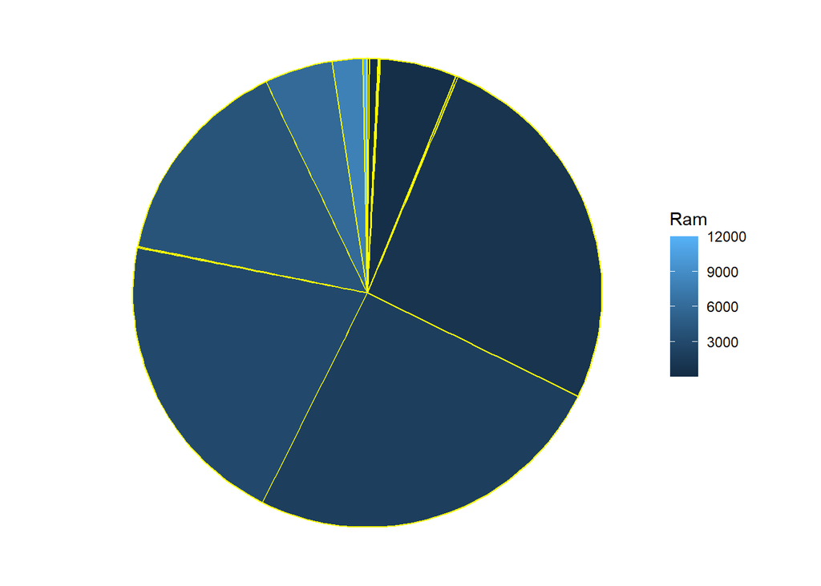

[6 more figures not shown]

# Phần 3: Kiểm định giả thuyết:

Do dataset của nhóm có 3 loại biến là binary, continuous và nominal, nên phần kiểm định giả thuyết nhóm sẽ áp dụng phương pháp kiểm kê cho phù hợp với từng trường hợp.

3 phương pháp kiểm kê mà nhóm sẽ sử dụng:

- Phân tích tương quan Pearson cho 2 biến continuous.
- One-way ANOVA F-test cho biến nominal và continuous.
- Phân tích tương quan Point Biserial cho biến binary và continous.

## *Biến phân loại:*

### **Brand**

Phương pháp: One-way ANOVA F-test.

H<sub>0</sub>: Không có sự khác biệt về giá trung bình giữa các hãng điện thoại.

H<sub>1</sub>: Có sự khác biệt về giá trung bình giữa các hãng điện thoại.

```r
new_data<-data
new_data<-new_data[order(new_data$Brand),]
new_brand = `as.factor`(new_data$Brand)
new_price = new_data$Price
new_brand<-as.numeric(new_brand)
summary(aov(new_price~new_brand))
```

```
##               Df   Sum Sq Mean Sq F value Pr(>F)
## new_brand      1    15956   15956    0.57   0.45
## Residuals   1359 38013023   27971
```

### Touchscreen

Phương pháp: Phân tích tương quan Point Biserial.

H<sub>0</sub>: Không có sự khác biệt về giá trung bình giữa điện thoại có cảm ứng và không có cảm ứng.

H<sub>1</sub>: Có sự khác biệt về giá trung bình giữa điện thoại có cảm ứng và không có cảm ứng.

```r
new_data<-data
new_data[new_data$Touchscreen == "Yes",]['Touchscreen']<-as.integer(1)
new_data[new_data$Touchscreen == "No",]['Touchscreen']<-as.integer(0)
new_data$Touchscreen<-as.numeric(new_data$Touchscreen)
cor.test(new_data$Price,new_data$Touchscreen)
```

```
##
##  Pearson's product-moment correlation
##
## data:  new_data$Price and new_data$Touchscreen
## t = 1.8668, df = 1359, p-value = 0.06214
## alternative hypothesis: true correlation is not equal to 0
## 95 percent confidence interval:
##  -0.002567902  0.103433065
## sample estimates:
##        cor
## 0.05057501
```

### Operating System

Phương pháp: One-way ANOVA F-test.

H<sub>0</sub>: Không có sự khác biệt về giá trung bình giữa điện thoại có hệ điều hành khác nhau.

H<sub>1</sub>: Có sự khác biệt về giá trung bình giữa điện thoại có hệ điều hành khác nhau.

```r
new_data<-data
new_data<-new_data[order(new_data$OS),]
new_OS = as.numeric(as.factor(new_data$OS))
new_price = new_data$Price
summary(aov(new_OS~new_price))
```

```
##               Df Sum Sq Mean Sq F value   Pr(>F)
## new_price      1   21.0  20.981   30.35 4.31e-08 ***
## Residuals   1359  939.5   0.691
## ---
## Signif. codes:  0 '***' 0.001 '**' 0.01 '*' 0.05 '.' 0.1 ' ' 1
```

### GPS:

Phương pháp: Phân tích tương quan Point Biserial.

H<sub>0</sub>: Không có mối quan hệ tuyến tính giữa GPS và giá.

H<sub>1</sub>: Có mối quan hệ tuyến tính nào giữa GPS và giá.

```r
new_data<-data
new_data[new_data$GPS == "Yes",]['GPS']<-as.integer(1)
new_data[new_data$GPS == "No",]['GPS']<-as.integer(0)
new_data$GPS<-as.numeric(new_data$GPS)
cor.test(new_data$Price,new_data$GPS)
```

```
##
##  Pearson's product-moment correlation
##
## data:  new_data$Price and new_data$GPS
## t = 2.4946, df = 1359, p-value = 0.01273
## alternative hypothesis: true correlation is not equal to 0
## 95 percent confidence interval:
##  0.01442987 0.12021886
## sample estimates:
##        cor
## 0.06751412
```

cor != 0=> Có mối quan hệ tuyến tính giữa GPS và giá.

### 3G

Phương pháp: Phân tích tương quan Point Biserial.

H<sub>0</sub>: Không có mối quan hệ tuyến tính giữa 3G và giá.

H<sub>1</sub>: Có mối quan hệ tuyến tính nào giữa 3G và giá.

```r
new_data<-data
new_data[new_data$`3G` == "Yes",]['3G']<-as.integer(1)
new_data[new_data$`3G` == "No",]['3G']<-as.integer(0)
new_data$`3G`<-as.numeric(new_data$`3G`)
cor.test(new_data$Price,new_data$`3G`)
```

```
##
##  Pearson's product-moment correlation
##
## data:  new_data$Price and new_data$`3G`
## t = -0.08899, df = 1359, p-value = 0.9291
## alternative hypothesis: true correlation is not equal to 0
## 95 percent confidence interval:
##  -0.05554285  0.05072856
## sample estimates:
##          cor
## -0.002413965
```

cor xấp xỉ 0=> Không mối quan hệ tuyến tính giữa 3G và giá.

### 4G

Phương pháp: Phân tích tương quan Point Biserial.

H<sub>0</sub>: Không có mối quan hệ tuyến tính giữa 4G và giá.

H<sub>1</sub>: Có mối quan hệ tuyến tính nào giữa 4G và giá.

```r
new_data<-data
new_data[new_data$`4G` == "Yes",]['4G']<-as.integer(1)
new_data[new_data$`4G` == "No",]['4G']<-as.integer(0)
new_data$`4G`<-as.numeric(new_data$`4G`)
cor.test(new_data$Price,new_data$`4G`)
```

```
##
##  Pearson's product-moment correlation
##
## data:  new_data$Price and new_data$`4G`
## t = 5.6337, df = 1359, p-value = 2.142e-08
## alternative hypothesis: true correlation is not equal to 0
## 95 percent confidence interval:
##  0.09872267 0.20257616
## sample estimates:
##       cor
## 0.1510662
```

cor != 0=> Có mối quan hệ tuyến tính giữa 4G và giá.

## *Biến liên tục:*

### Battery Capacity

Phương pháp: Phân tích tương quan Pearson.

H<sub>0</sub>: Không có mối quan hệ tuyến tính giữa battery capacity và giá.

H<sub>1</sub>: Có mối quan hệ tuyến tính giữa battery capacity và giá.

```r
result<-cor.test(data$Price,data$Battery,method = 'pearson')
print(result)
```

```
##
##  Pearson's product-moment correlation
##
## data:  data$Price and data$Battery
## t = 11.667, df = 1359, p-value < 2.2e-16
## alternative hypothesis: true correlation is not equal to 0
## 95 percent confidence interval:
##  0.2526534 0.3492746
## sample estimates:
##       cor
## 0.3017386
```

cor != 0=> Có mối quan hệ tuyến tính giữa battery capacity và giá.

### Screensize

Phương pháp: Phân tích tương quan Pearson.

H<sub>0</sub>: Không có mối quan hệ tuyến tính giữa screensize và giá.

H<sub>1</sub>: Có mối quan hệ tuyến tính giữa screensize và giá.

```r
result<-cor.test(data$Price,data$Screensize,method = 'pearson')
print(result)
```

```
##
##  Pearson's product-moment correlation
##
## data:  data$Price and data$Screensize
## t = 16.309, df = 1359, p-value < 2.2e-16
## alternative hypothesis: true correlation is not equal to 0
## 95 percent confidence interval:
##  0.3591628 0.4480810
## sample estimates:
##       cor
## 0.4045777
```

cor != 0=> Có mối quan hệ tuyến tính giữa screensize và giá.

### Resolution.x

Phương pháp: Phân tích tương quan Pearson.

H<sub>0</sub>: Không có mối quan hệ tuyến tính giữa resolution.x và giá

H<sub>1</sub>: Có mối quan hệ tuyến tính giữa resolution.x và giá

```r
result<-cor.test(data$Price,data$Resolution.x,method = 'pearson')
print(result)
```

```
##
##  Pearson's product-moment correlation
##
## data:  data$Price and data$Resolution.x
## t = 23.755, df = 1359, p-value < 2.2e-16
## alternative hypothesis: true correlation is not equal to 0
## 95 percent confidence interval:
##  0.5030081 0.5781619
## sample estimates:
##       cor
## 0.5416666
```

cor != 0=> Có mối quan hệ tuyến tính giữa Resolution.x và giá.

### Resolution.y

Phương pháp: Phân tích tương quan Pearson.

H<sub>0</sub>: Không có mối quan hệ tuyến tính giữa resolution.y và giá

H<sub>1</sub>: Có mối quan hệ tuyến tính giữa resolution.y và giá

```r
result<-cor.test(data$Price,data$Resolution.y,method = 'pearson')
print(result)
```

```
##
##  Pearson's product-moment correlation
##
## data:  data$Price and data$Resolution.y
## t = 26.128, df = 1359, p-value < 2.2e-16
## alternative hypothesis: true correlation is not equal to 0
## 95 percent confidence interval:
##  0.5417585 0.6125630
## sample estimates:
##       cor
## 0.5782485
```

cor != 0=> Có mối quan hệ tuyến tính giữa Resolution.y và giá.

### NumOfProcessor

Phương pháp: Phân tích tương quan Pearson.

H<sub>0</sub>: Không có mối quan hệ tuyến tính giữa NumOfProcessor và giá

H<sub>1</sub>: Có mối quan hệ tuyến tính giữa NumOfProcessor và giá

```r
result<-cor.test(data$Price,data$NumOfProcessor,method = 'pearson')
print(result)
```

```
##
##  Pearson's product-moment correlation
##
## data:  data$Price and data$NumOfProcessor
## t = 11.651, df = 1359, p-value < 2.2e-16
## alternative hypothesis: true correlation is not equal to 0
## 95 percent confidence interval:
##  0.252270 0.348915
## sample estimates:
##       cor
## 0.3013663
```

cor != 0=> Có mối quan hệ tuyến tính giữa NumOfProcessor và giá.

### RAM

Phương pháp: Phân tích tương quan Pearson.

H<sub>0</sub>: Không có mối quan hệ tuyến tính giữa ram và giá

H<sub>1</sub>: Có mối quan hệ tuyến tính giữa ram và giá

```r
result<-cor.test(data$Price,data$Ram,method = 'pearson')
print(result)
```

```
##
##  Pearson's product-moment correlation
##
## data:  data$Price and data$Ram
## t = 28.749, df = 1359, p-value < 2.2e-16
## alternative hypothesis: true correlation is not equal to 0
## 95 percent confidence interval:
##  0.5808059 0.6469587
## sample estimates:
##       cor
## 0.6149631
```

cor != 0=> Có mối quan hệ tuyến tính giữa RAM và giá.

### Internal storage

Phương pháp: Phân tích tương quan Pearson.

H<sub>0</sub>: Không có mối quan hệ tuyến tính giữa Internal storage và giá

H<sub>1</sub>: Có mối quan hệ tuyến tính giữa Internal storage và giá

```r
result<-cor.test(data$InternalStorage,data$Price,method = 'pearson')
print(result)
```

```
##
##  Pearson's product-moment correlation
##
## data:  data$InternalStorage and data$Price
## t = 31.251, df = 1359, p-value < 2.2e-16
## alternative hypothesis: true correlation is not equal to 0
## 95 percent confidence interval:
##  0.6146264 0.6765340
## sample estimates:
##       cor
## 0.6466438
```

cor != 0=> Có mối quan hệ tuyến tính giữa Internal storage và giá.

### Rear Camera

Phương pháp: Phân tích tương quan Pearson.

H<sub>0</sub>: Không có mối quan hệ tuyến tính giữa Rear Camera và giá

H<sub>1</sub>: Có mối quan hệ tuyến tính giữa Rear Camera và giá

```r
result<-cor.test(data$RearCamera,data$Price,method = 'pearson')
print(result)
```

```
##
##  Pearson's product-moment correlation
##
## data:  data$RearCamera and data$Price
## t = 14.97, df = 1359, p-value < 2.2e-16
## alternative hypothesis: true correlation is not equal to 0
## 95 percent confidence interval:
##  0.3296946 0.4209597
## sample estimates:
##       cor
## 0.3762394
```

cor != 0=> Có mối quan hệ tuyến tính giữa Rear Camera và giá.

### Front camera

Phương pháp: Phân tích tương quan Pearson.

H<sub>0</sub>: Không có mối quan hệ tuyến tính giữa Front camera và giá

H<sub>1</sub>: Có mối quan hệ tuyến tính giữa Front camera và giá

```r
result<-cor.test(data$FrontCamera,data$Price,method = 'pearson')
print(result)
```

```
##
##  Pearson's product-moment correlation
##
## data:  data$FrontCamera and data$Price
## t = 12.089, df = 1359, p-value < 2.2e-16
## alternative hypothesis: true correlation is not equal to 0
## 95 percent confidence interval:
##  0.2628265 0.3588057
## sample estimates:
##       cor
## 0.3116107
```

cor != 0=> Có mối quan hệ tuyến tính giữa Front camera và giá.

### NumOfSims

Phương pháp: Phân tích tương quan Pearson.

H<sub>0</sub>: Không có mối quan hệ tuyến tính giữa NumOfSims và giá

H<sub>1</sub>: Có mối quan hệ tuyến tính giữa NumOfSims và giá

```r
result<-cor.test(data$Price,data$NumOfSims)
print(result)
```

```
##
##  Pearson's product-moment correlation
##
## data:  data$Price and data$NumOfSims
## t = -6.1103, df = 1359, p-value = 1.296e-09
## alternative hypothesis: true correlation is not equal to 0
## 95 percent confidence interval:
##  -0.2147887 -0.1113504
## sample estimates:
##        cor
## -0.1635189
```

cor != 0=> Có mối quan hệ tuyến tính giữa NumOfSims và giá.

Wifi và Bluetooth:

Do mẫu điện thoại không có wifi và bluetooth quá ít nên không thể kiểm định.

# Phần 4: Mô hình hoá dữ liệu

Chỉnh sửa lại data để phù hợp với hàm tuyến tính:

```r
new_data<-data
#new_data$Model<-as.numeric(as.factor(new_data$Model))
#Đổi biến Touchscreen về dạng số
new_data[new_data$Touchscreen == "Yes",]$Touchscreen<-as.integer(1)
new_data[new_data$Touchscreen == "No",]$Touchscreen<-as.integer(0)
new_data$Touchscreen<-as.numeric(new_data$Touchscreen)
#Đổi biến OS về dạng số
new_data$OS = as.numeric(as.factor(new_data$OS))
#Đổi biến Bluetooth về dạng số
new_data[new_data$Bluetooth == "Yes",]['Bluetooth']<-as.integer(1)
new_data[new_data$Bluetooth == "No",]['Bluetooth']<-as.integer(0)
new_data$Bluetooth<-as.numeric(new_data$Bluetooth)
#Đổi biến Wifi về dạng số
new_data[new_data$Wifi == "Yes",]['Wifi']<-as.integer(1)
new_data[new_data$Wifi == "No",]['Wifi']<-as.integer(0)
new_data$Wifi<-as.numeric(new_data$Wifi)
#Đổi biến GPS về dạng số
new_data[new_data$GPS == "Yes",]['GPS']<-as.integer(1)
new_data[new_data$GPS == "No",]['GPS']<-as.integer(0)
new_data$GPS<-as.numeric(new_data$GPS)
#Đổi biến 3G về dạng số
new_data[new_data$`3G` == "Yes",]['3G']<-as.integer(1)
new_data[new_data$`3G` == "No",]['3G']<-as.integer(0)
new_data$`3G`<-as.numeric(new_data$`3G`)
#Đổi biến 4G về dạng số
new_data[new_data$`4G` == "Yes",]['4G']<-as.integer(1)
new_data[new_data$`4G` == "No",]['4G']<-as.integer(0)
new_data$`4G`<-as.numeric(new_data$`4G`)

head(new_data,10)
```

```
##    X                           Name   Brand                  Model Battery
## 1  0 OnePlus 7T Pro McLaren Edition OnePlus 7T Pro McLaren Edition    4085
## 2  1                  Realme X2 Pro  Realme                 X2 Pro    4000
## 3  2              iPhone 11 Pro Max   Apple      iPhone 11 Pro Max    3969
## 4  3                      iPhone 11   Apple              iPhone 11    3110
## 5  4                   LG G8X ThinQ      LG              G8X ThinQ    4000
## 6  5                     OnePlus 7T OnePlus                     7T    3800
## 7  6                 OnePlus 7T Pro OnePlus                 7T Pro    4085
## 8  7        Samsung Galaxy Note 10+ Samsung        Galaxy Note 10+    4300
## 9  8               Asus ROG Phone 2    Asus            ROG Phone 2    6000
## 10 9           Xiaomi Redmi K20 Pro  Xiaomi          Redmi K20 Pro    4000
##    Screensize Touchscreen Resolution.x Resolution.y NumOfProcessor   Ram
## 1        6.67           1         1440         3120              8 12000
## 2        6.50           1         1080         2400              8  6000
## 3        6.50           1         1242         2688              6  4000
```

[output cut: 29 more lines]

Tạo ra bảng brand_numOfPhone để lưu số lượng điện thoại cho từng hãng:

```
##      brand numOfPhone
## 1    Apple         19
## 2     Asus         37
## 3  Coolpad         19
## 4   Gionee         33
## 5    Honor         33
## 6      HTC         35
## 7  InFocus         19
## 8    Intex        117
## 9  Karbonn         34
## 10    Lava         59
```

Tách ra làm tập dữ liệu để Training và Test:

```r
inTrain<-createDataPartition(new_data$Price,p=0.8,list=FALSE)
train_data<-new_data[inTrain,]
test_data<-new_data[-inTrain,]
train_data
```

```
##         X                               Name     Brand
## 1       2                  iPhone 11 Pro Max     Apple
## 12     21                    Apple iPhone XR     Apple
## 26     39                     Apple iPhone 8     Apple
## 27     40                Apple iPhone 8 Plus     Apple
## 28     41                     Apple iPhone X     Apple
## 36     51                Apple iPhone 7 Plus     Apple
## 37     52                     Apple iPhone 7     Apple
## 142   192                    Apple iPhone SE     Apple
## 149   200                    Apple iPhone 6s     Apple
## 170   222                Apple iPhone 6 Plus     Apple
## 171   223                     Apple iPhone 6     Apple
## 187   240                    Apple iPhone 5c     Apple
## 498   630                      iPhone 11 Pro     Apple
## 1013 1360                Ipad iPad (9th Gen)     Apple
```

[output cut: 3233 more lines]

```r
test_data
```

```
##         X                          Name     Brand                    Model
## 2       3                     iPhone 11     Apple                iPhone 11
## 13     22           Apple iPhone XS Max     Apple            iPhone XS Max
## 14     23               Apple iPhone XS     Apple                iPhone XS
## 44     61          Apple iPhone 6s Plus     Apple           iPhone 6s Plus
## 1012 1359              iPhone 13 promax     Apple               13 Pro Max
## 15     26                Asus ROG Phone      Asus                ROG Phone
## 18     29       Asus ZenFone Max Pro M1      Asus       ZenFone Max Pro M1
## 221   285 Asus ZenFone Max M1 (ZB556KL)      Asus ZenFone Max M1 (ZB556KL)
## 308   393              Asus ZenFone Max      Asus              ZenFone Max
## 477   601             Asus ZenFone Live      Asus             ZenFone Live
## 648   868                Asus ZenFone 4      Asus                ZenFone 4
## 114   158           Coolpad Cool Play 6   Coolpad              Cool Play 6
## 260   339           Coolpad Note 5 Lite   Coolpad              Note 5 Lite
## 282   361           Coolpad Cool 1 Dual   Coolpad              Cool 1 Dual
```

[output cut: 797 more lines]

Tạo ra bảng OStoNum để quy đổi OS ra số

```r
OStoNum<-data.frame(OS = unique(data[order(data$OS),]$OS))
OStoNum$Num<-c(1:nrow(OStoNum))
OStoNum
```

```
##           OS Num
## 1    Android   1
## 2 BlackBerry   2
## 3   Cyanogen   3
## 4        iOS   4
## 5   Sailfish   5
## 6      Tizen   6
## 7    Windows   7
```

Cùng xem lại new_data sau khi chuyển đổi:

```r
head(new_data)
```

```
##     X                Name Brand             Model Battery Screensize
## 1   2   iPhone 11 Pro Max Apple iPhone 11 Pro Max    3969        6.5
## 2   3           iPhone 11 Apple         iPhone 11    3110        6.1
## 12 21     Apple iPhone XR Apple         iPhone XR    2942        6.1
## 13 22 Apple iPhone XS Max Apple     iPhone XS Max    2658        6.5
## 14 23     Apple iPhone XS Apple         iPhone XS    2658        5.8
## 26 39      Apple iPhone 8 Apple          iPhone 8    1821        4.7
##    Touchscreen Resolution.x Resolution.y NumOfProcessor  Ram InternalStorage
## 1            1         1242         2688              6 4000              64
## 2            1          828         1792              6 4000              64
## 12           1          828         1792              6 3000              64
## 13           1         1242         2688              6 4000              64
## 14           1         1125         2436              6 4000              64
## 26           1          750         1334              6 2000              64
##    RearCamera FrontCamera OS Wifi Bluetooth GPS NumOfSims 3G 4G    Price
## 1          12          12  4    1         1   1         2  1  1 1282.800
## 2          12          12  4    1         1   1         2  1  1  754.800
## 12         12           7  4    1         1   1         2  1  1  545.988
## 13         12           7  4    1         1   1         2  1  1  839.988
## 14         12           7  4    1         1   1         2  1  1  719.988
## 26         12           7  4    1         1   1         1  1  1  443.988
```

```r
#test_data<-read.csv('./test_data.csv')
#colnames(test_data)[5]<-'Battery'
#colnames(test_data)[6]<-'Screensize'
#colnames(test_data)[10]<-'NumOfProcessor'
##colnames(test_data)[11]<-'Ram'
#colnames(test_data)[12]<-'InternalStorage'
#colnames(test_data)[13]<-'RearCamera'
#colnames(test_data)[14]<-'FrontCamera'
#colnames(test_data)[15]<-'OS'
#colnames(test_data)[16]<-'Wifi'
#colnames(test_data)[19]<-'NumOfSims'
#colnames(test_data)[20]<-'3G'
#colnames(test_data)[21]<-'4G'
#test_data[test_data$Touchscreen == "Yes",]$Touchscreen<-as.integer(1)
#test_data[test_data$Touchscreen == "No",]$Touchscreen<-as.integer(0)
#test_data$Touchscreen<-as.numeric(test_data$Touchscreen)

#for (i in 1:nrow(test_data))
#{
#    for (j in 1:nrow(OStoNum))
#    {
#      if (test_data[i,]$OS==OStoNum[j,]$OS)
#      {
#        test_data[i,]$OS = OStoNum[j,]$Num
#      }
#    }
#}
#regression_data$Brand<-as.numeric(as.factor(regression_data$Brand))
#test_data$OS<-as.numeric(test_data$OS)
#test_data[test_data$Bluetooth == "Yes",]['Bluetooth']<-as.integer(1)
#test_data[test_data$Bluetooth == "No",]['Bluetooth']<-as.integer(0)
#test_data$Bluetooth<-as.numeric(test_data$Bluetooth)

#test_data[test_data$Wifi == "Yes",]['Wifi']<-as.integer(1)
#test_data[test_data$Wifi == "No",]['Wifi']<-as.integer(0)
#test_data$Wifi<-as.numeric(test_data$Wifi)

#test_data[test_data$GPS == "Yes",]['GPS']<-as.integer(1)
#test_data[test_data$GPS == "No",]['GPS']<-as.integer(0)
#test_data$GPS<-as.numeric(test_data$GPS)

#test_data[test_data$`3G` == "Yes",]['3G']<-as.integer(1)
#test_data[test_data$`3G` == "No",]['3G']<-as.integer(0)
#test_data$`3G`<-as.numeric(test_data$`3G`)

#test_data[test_data$`4G` == "Yes",]['4G']<-as.integer(1)
#test_data[test_data$`4G` == "No",]['4G']<-as.integer(0)
#test_data$`4G`<-as.numeric(test_data$`4G`)

#head(test_data,10)
```

**Mô hình dự đoán giá điện thoại cho tất cả điện thoại**

```r
regression_data<-train_data
regression_data$Brand<-as.numeric(as.factor(regression_data$Brand))
regression<-lm(regression_data$Price ~
     regression_data$Brand+
     regression_data$Battery+
     regression_data$Screensize+
     regression_data$Touchscreen+
     regression_data$Resolution.x+
     regression_data$Resolution.y+
     regression_data$NumOfProcessor+
     regression_data$Ram+
     regression_data$InternalStorage+
     regression_data$RearCamera+
     regression_data$FrontCamera+
     regression_data$OS+
     regression_data$Wifi+
     regression_data$Bluetooth+
     regression_data$GPS+
     regression_data$NumOfSims+
     regression_data$`3G`+
     regression_data$`4G`
   ,data = regression_data)
summary(regression)
```

```
##
## Call:
## lm(formula = regression_data$Price ~ regression_data$Brand +
##     regression_data$Battery + regression_data$Screensize + regression_data$Touchscreen +
##     regression_data$Resolution.x + regression_data$Resolution.y +
##     regression_data$NumOfProcessor + regression_data$Ram + regression_data$InternalStorage +
##     regression_data$RearCamera + regression_data$FrontCamera +
##     regression_data$OS + regression_data$Wifi + regression_data$Bluetooth +
##     regression_data$GPS + regression_data$NumOfSims + regression_data$`3G` +
##     regression_data$`4G`, data = regression_data)
##
## Residuals:
##     Min      1Q  Median      3Q     Max
## -358.15  -46.48   -8.95   24.00  910.56
##
## Coefficients:
##                                   Estimate Std. Error t value Pr(>|t|)
## (Intercept)                     -62.160432  90.927057  -0.684 0.494409
## regression_data$Brand             0.038089   0.661012   0.058 0.954064
## regression_data$Battery          -0.011069   0.006963  -1.590 0.112301
## regression_data$Screensize       -0.384833  11.136270  -0.035 0.972442
## regression_data$Touchscreen       4.002756  46.466328   0.086 0.931374
## regression_data$Resolution.x      0.104829   0.034742   3.017 0.002631 **
## regression_data$Resolution.y      0.049750   0.019990   2.489 0.013025 *
## regression_data$NumOfProcessor   -9.114990   2.535008  -3.596 0.000344 ***
## regression_data$Ram               0.026567   0.006017   4.415 1.15e-05 ***
## regression_data$InternalStorage   1.800185   0.195613   9.203  < 2e-16 ***
## regression_data$RearCamera       -0.162004   0.626751  -0.258 0.796101
## regression_data$FrontCamera      -4.838659   0.951854  -5.083 4.63e-07 ***
## regression_data$OS               22.974404   5.206952   4.412 1.16e-05 ***
## regression_data$Wifi             -5.831394  53.805137  -0.108 0.913722
## regression_data$Bluetooth       -11.688488  49.392302  -0.237 0.812993
## regression_data$GPS              39.071289  16.632841   2.349 0.019066 *
## regression_data$NumOfSims       -15.637088  11.589698  -1.349 0.177651
## regression_data$`3G`             29.558913  14.842331   1.992 0.046766 *
## regression_data$`4G`             -5.642536  10.384631  -0.543 0.587039
## ---
## Signif. codes:  0 '***' 0.001 '**' 0.01 '*' 0.05 '.' 0.1 ' ' 1
##
## Residual standard error: 110.8 on 792 degrees of freedom
## Multiple R-squared:  0.5323, Adjusted R-squared:  0.5217
## F-statistic: 50.09 on 18 and 792 DF,  p-value: < 2.2e-16
```

```r
regression_data<-test_data
regression_data$Brand<-as.numeric(as.factor(regression_data$Brand))
PredictedPrice = predict(regression,regression_data)
oneForAll<-regression_data%>%mutate(PredictedPrice = predict(regression,regression_data))
oneForAll<-oneForAll%>%mutate(error= PredictedPrice-Price,sq.error = error^2)
oneForAll<-oneForAll[c('Name','Price','PredictedPrice','error','sq.error')]
oneForAll
```

```
##                               Name    Price PredictedPrice         error
## 2                        iPhone 11  754.800      293.93011 -4.608699e+02
## 13             Apple iPhone XS Max  839.988      410.94786 -4.290401e+02
## 14                 Apple iPhone XS  719.988      386.41529 -3.335727e+02
## 44            Apple iPhone 6s Plus  311.880      286.47079 -2.540921e+01
## 1012              iPhone 13 promax  791.988      545.15205 -2.468359e+02
## 15                  Asus ROG Phone  839.988      482.56066 -3.574273e+02
## 18         Asus ZenFone Max Pro M1  119.880      165.68092  4.580092e+01
## 221  Asus ZenFone Max M1 (ZB556KL)   71.988       64.32848 -7.659520e+00
## 308               Asus ZenFone Max   59.988       79.95727  1.996927e+01
## 477              Asus ZenFone Live   55.188      106.16265  5.097465e+01
## 648                 Asus ZenFone 4   77.988      320.88713  2.428991e+02
## 114            Coolpad Cool Play 6  107.988      233.04919  1.250612e+02
## 260            Coolpad Note 5 Lite   51.480      119.91207  6.843207e+01
## 282            Coolpad Cool 1 Dual  151.668      165.03693  1.336893e+01
```

[output cut: 391 more lines]

```r
mse<-mean(oneForAll$sq.error)
rmse<-sqrt(mse)
rmse
```

```
## [1] 133.5075
```

```r
t.test(oneForAll$error,conf.level = 0.95)
```

```
##
##  One Sample t-test
##
## data:  oneForAll$error
## t = 0.11863, df = 201, p-value = 0.9057
## alternative hypothesis: true mean is not equal to 0
## 95 percent confidence interval:
##  -17.45081  19.68503
## sample estimates:
## mean of x
##  1.117113
```

**Mô hình tuyến tính cho mỗi hãng:**

```r
fn_RegressionBasedOnBrand<-function(test_data,new_data){
  #Sắp xếp lại theo Brand
  test_data<-test_data[order(test_data$Brand),]
  #result lưu trữ giá dự đoán
  result<-data.frame(Name = test_data$Name,
                     Price = test_data$Price,
                     PredictedPrice=NA)
  #lặp từng dòng
  for (i in 1:nrow(test_data))
  {
    #Kiểm tra điều kiện
    if (!test_data[i,]$Brand %in% new_data$Brand)
    {
      print(paste("Brand",test_data[i,]$Brand, "không tồn tại trong database!"))
      next
    }
    else if (!test_data[i,]$OS %in% new_data$OS)
    {
      print(paste("OS không tồn tại trong database!"))
      next
    }
    #Tạo model cho Brand ở hiện tại
    regression_data<-new_data[new_data$Brand == test_data[i,]$Brand,]
    regression<-lm(regression_data$Price ~
     regression_data$Battery+
     regression_data$Screensize+
     regression_data$Touchscreen+
     regression_data$Resolution.x+
     regression_data$Resolution.y+
     regression_data$NumOfProcessor+
     regression_data$Ram+
     regression_data$InternalStorage+
     regression_data$RearCamera+
     regression_data$FrontCamera+
     regression_data$OS+
     regression_data$Wifi+
     regression_data$Bluetooth+
     regression_data$GPS+
     regression_data$NumOfSims+
     regression_data$`3G`+
     regression_data$`4G`
   ,data = regression_data)
    regression_data<-test_data[i,]
    #Đoán giá ở dòng hiện tại
    result[i,]$PredictedPrice <- predict(regression,regression_data)
  }
  return(result)
}
suppressWarnings({
  modelForeachBrand<-fn_RegressionBasedOnBrand(test_data,train_data)
})
```

```
## [1] "OS không tồn tại trong database!"
```

```r
modelForeachBrand<-modelForeachBrand%>%
  mutate(error= PredictedPrice-Price,sq.error = error^2)
print(modelForeachBrand)
```

```
##                              Name    Price PredictedPrice         error
## 1                       iPhone 11  754.800   1419.9554600  6.651555e+02
## 2             Apple iPhone XS Max  839.988    457.8900608 -3.820979e+02
## 3                 Apple iPhone XS  719.988    558.0313894 -1.619566e+02
## 4            Apple iPhone 6s Plus  311.880    346.3325891  3.445259e+01
## 5                iPhone 13 promax  791.988   3186.2330007  2.394245e+03
## 6                  Asus ROG Phone  839.988    424.7442952 -4.152437e+02
## 7         Asus ZenFone Max Pro M1  119.880    210.1841975  9.030420e+01
## 8   Asus ZenFone Max M1 (ZB556KL)   71.988    133.9149849  6.192698e+01
## 9                Asus ZenFone Max   59.988    162.5982542  1.026103e+02
## 10              Asus ZenFone Live   55.188    105.2525555  5.006456e+01
## 11                 Asus ZenFone 4   77.988    304.4402318  2.264522e+02
## 12            Coolpad Cool Play 6  107.988    185.0319880  7.704399e+01
## 13            Coolpad Note 5 Lite   51.480     68.8990016  1.741900e+01
## 14            Coolpad Cool 1 Dual  151.668     74.4819164 -7.718608e+01
```

[output cut: 391 more lines]

```r
mse_ForeachBrand<-mean(na.omit(modelForeachBrand$sq.error))
rmse_ForeachBrand<-sqrt(mse_ForeachBrand)
rmse_ForeachBrand
```

```
## [1] 237.5586
```

```r
t.test(na.omit(modelForeachBrand$error),conf.level = 0.95)
```

```
##
##  One Sample t-test
##
## data:  na.omit(modelForeachBrand$error)
## t = 0.62283, df = 200, p-value = 0.5341
## alternative hypothesis: true mean is not equal to 0
## 95 percent confidence interval:
##  -22.63965  43.54376
## sample estimates:
## mean of x
##  10.45205
```

```r
#regression_train<-regression_train%>%
#                    mutate(error= PredictedPrice-Price,sq.error = error^2)
#regression_train[c('Name','Price','PredictedPrice','error','sq.error')]
#mse<-mean(regression_train$sq.error)
#rmse<-sqrt(mse)
#rmse
```

k-NN:

One-hot encoding:

```r
kNN_train_data<-train_data

#Thêm cột cho tập kNN_train_data theo
for (i in 1:nrow(brand_numOfPhone))
{
  #Lấy giá unique trong cột Brand rồi tạo cột mới theo Brand đó
  new_column_name<-brand_numOfPhone[i,]$brand
  #Gán tất cả giá trị của cột đó bằng 0
  kNN_train_data[new_column_name]<-0
}
#Gán encoding cho tập kNN_train_data:
for (i in 1:nrow(kNN_train_data))
{
  #Lấy Brand của cột đó
  column_name<-kNN_train_data[i,]$Brand
  #Gán giá trị 1 với cột có tên giống với column_name
  kNN_train_data[i,column_name]<-1
}
kNN_train_data<-subset(kNN_train_data,select = -c(X,Name,Brand,Model))
kNN_train_data
```

```
##      Battery Screensize Touchscreen Resolution.x Resolution.y NumOfProcessor
## 1       3969       6.50           1         1242         2688              6
## 12      2942       6.10           1          828         1792              6
## 26      1821       4.70           1          750         1334              6
## 27      2691       5.50           1         1080         1920              6
## 28      2716       5.80           1         1125         2436              6
## 36      2900       5.50           1         1080         1920              4
## 37      1960       4.70           1          750         1334              4
## 142     1624       4.00           1          640         1136              1
## 149     1715       4.70           1          750         1334              2
## 170     2915       5.50           1         1080         1920              1
## 171     1810       4.70           1          750         1334              2
## 187     1507       4.00           1          640         1136              2
## 498     3046       5.80           1         1125         2436              6
## 1013    8557      10.20           1         2160         1620              6
```

[output cut: 4045 more lines]

```r
kNN_test_data<-test_data
#Thêm cột cho tập kNN_test_data theo
for (i in 1:nrow(brand_numOfPhone))
{
  #Lấy giá unique trong cột Brand rồi tạo cột mới theo Brand đó
  new_column_name<-brand_numOfPhone[i,]$brand
  #Gán tất cả giá trị của cột đó bằng 0
  kNN_test_data[new_column_name]<-0
}
#Gán encoding cho tập kNN_test_data:
for (i in 1:nrow(kNN_test_data))
{
  #Lấy Brand của cột đó
  column_name<-kNN_test_data[i,]$Brand
  #Gán giá trị 1 với cột có tên giống với column_name
  kNN_test_data[i,column_name]<-1
}
kNN_test_data<-subset(kNN_test_data,select = -c(X,Name,Brand,Model))

kNN_test_data
```

```
##      Battery Screensize Touchscreen Resolution.x Resolution.y NumOfProcessor
## 2       3110       6.10           1          828         1792              6
## 13      2658       6.50           1         1242         2688              6
## 14      2658       5.80           1         1125         2436              6
## 44      2750       5.50           1         1080         1920              1
## 1012    4352       6.70           1         1284         2778              6
## 15      4000       6.00           1         1080         2160              8
## 18      5000       5.99           1         1080         2160              8
## 221     4000       5.45           1          720         1440              8
## 308     5000       5.50           1          720         1280              4
## 477     2650       5.00           1          720         1280              4
## 648     3300       5.50           1         1080         1920              1
## 114     4060       5.50           1         1080         1920              8
## 260     2500       5.00           1          720         1280              4
## 282     4000       5.50           1         1080         1920              8
```

[output cut: 1000 more lines]

```r
set.seed(1)
#inTrain<-createDataPartition(kNNdata$Price,p=0.8,list=FALSE)
#knn_training<-kNNdata[inTrain,]
#knn_test<-kNNdata[-inTrain,]

#knn_test<-as.data.frame(do.call(cbind, knn_test))
#knn_training<-as.data.frame(do.call(cbind, knn_training))

tuneGrid<-expand.grid(k=seq(1,59, by=2))

kNNModel<-train(Price~.,data = kNN_train_data, method = 'knn',
                preProcess = c('center','scale'),
                trControl = trainControl(method ='repeatedcv',number=10,repeats = 5),tuneGrid = tuneGrid)

summary(kNNModel)
```

```
##             Length Class      Mode
## learn        2     -none-     list
## k            1     -none-     numeric
## theDots      0     -none-     list
## xNames      40     -none-     character
## problemType  1     -none-     character
## tuneValue    1     data.frame list
## obsLevels    1     -none-     logical
## param        0     -none-     list
```

```r
#kNNModel$results
kNN_result<-data.frame(Price = kNN_test_data$Price,
                       PredictedPrice = predict(kNNModel,kNN_test_data))
#knn_rmse<-sqrt(mean(kNN_result$Price-kNN_result$PredictedPrice)^2)
kNN_result<-kNN_result%>%
  mutate(error= PredictedPrice-Price,sq.error = error^2)
knn_rmse<-sqrt(mean(kNN_result$sq.error))
kNN_result
```

```
##        Price PredictedPrice     error     sq.error
## 1    754.800        997.196   242.396 5.875582e+04
## 2    839.988        997.196   157.208 2.471436e+04
## 3    719.988        997.196   277.208 7.684428e+04
## 4    311.880        327.988    16.108 2.594677e+02
## 5    791.988        997.196   205.208 4.211032e+04
## 6    839.988        335.988  -504.000 2.540160e+05
## 7    119.880        190.388    70.508 4.971378e+03
## 8     71.988        109.988    38.000 1.444000e+03
## 9     59.988        132.396    72.408 5.242918e+03
## 10    55.188         63.916     8.728 7.617798e+01
## 11    77.988        144.432    66.444 4.414805e+03
## 12   107.988         81.292   -26.696 7.126764e+02
## 13    51.480         63.952    12.472 1.555508e+02
## 14   151.668        101.192   -50.476 2.547827e+03
```

[output cut: 188 more lines]

```r
knn_rmse
```

```
## [1] 144.3109
```

```r
min(abs(kNN_result$error))
```

```
## [1] 0.188
```

```r
max(abs(kNN_result$error))
```

```
## [1] 1596.288
```

```r
t.test(kNN_result$error,conf.level = 0.95)
```

```
##
##  One Sample t-test
##
## data:  kNN_result$error
## t = -1.0051, df = 201, p-value = 0.3161
## alternative hypothesis: true mean is not equal to 0
## 95 percent confidence interval:
##  -30.225822   9.815951
## sample estimates:
## mean of x
## -10.20494
```

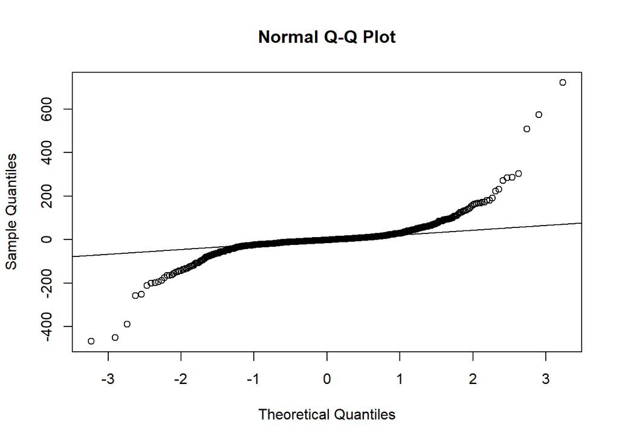

```r
qqnorm(resid(kNNModel))
qqline(resid(kNNModel))
```

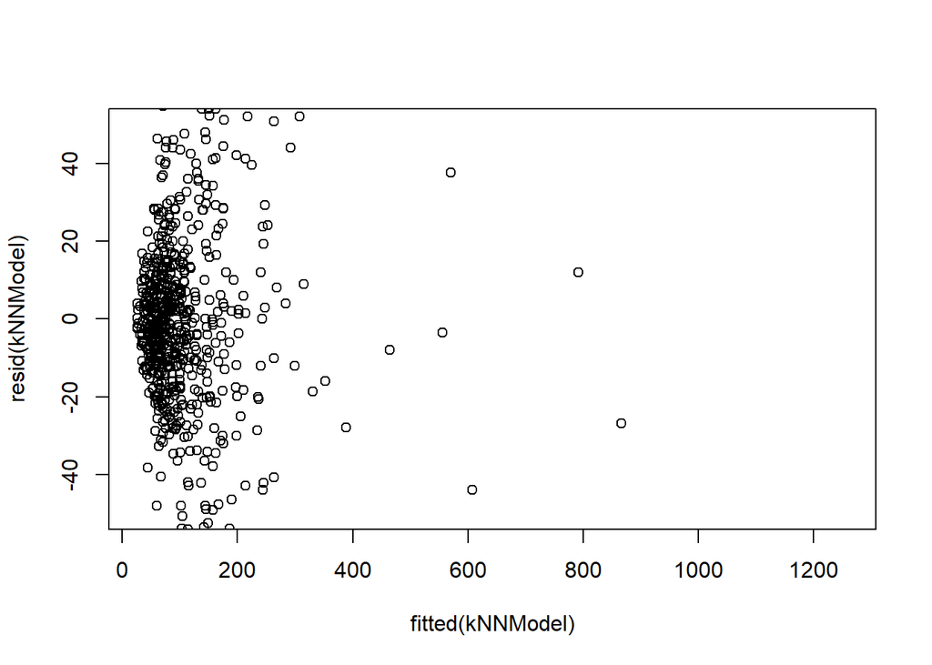

```r
plot(fitted(kNNModel),resid(kNNModel),ylim=c(-50,50))
```